# Using Machine Learning Algorithms to predict an ADHD diagnosis from FMRI data

## Dataset

Dataset from Study: Pierre Bellec, Carlton Chu, François Chouinard-Decorte, Yassine Benhajali, Daniel S. Margulies, R. Cameron Craddock (2017). The Neuro Bureau ADHD-200 Preprocessed repository. NeuroImage, 144, Part B, pp. 275 - 286. doi:10.1016/j.neuroimage.2016.06.034

This notebook contains an analysis of the ADHD-200 dataset available on Nilearn. The dataset contains resting state fMRI data from 40 subjects and their phenotypic information. Half of the subjects are patients diagnosed with ADHD and the remaining half are healthy controls. The subjects in the study are all children and adolescents. The analysis in this notebook is my attempt to predict ADHD diagnosis using resting state fMRI data.

I have modified the phenotypic file and used an imported file ("phenotypics.csv") instead of the phenotypic file that comes with Nilearn dataset since it did not contain information about the differentiation between healthy and patient - subject types - I derived that information based on the dataset supplied at "http://preprocessed-connectomes-project.org/adhd200/download.html".

## Background

This project uses machine learning techniques to predict ADHD diagnosis from fMRI data.

The data used in this project comes from the ADHD-200 study.

Machine learning algorithms are used in this project to classify patients with ADHD from healthy controls. My aim for this project is to gain experience with processing fMRI data using programming languages as well as with FSL. I will further experiement with different machine learning techniques (algorithms/ classifiers, cross-validation methods for multi-voxel pattern analysis and also fine-tweaking the hyperparameters of the classifying models) and compare how they do with each implementation.

## Tools and Software Used

This project has used the following technologies:

- Processing of fMRI data and visualization of fMRI data with `nilearn`
- Interactive visualizations are created with `ipywidgets` and `plotly.express`
- Machine learning analysis is done with `scikit-learn`
- The results and information presented in this notebook is through `Jupyter Notebook`
- Data manipulation is done with `pandas`
- This project is hosted on Github.

```python
#import data
from nilearn import datasets
data = datasets.fetch_adhd(n_subjects=None)
#from nilearn.image import smooth_img
#data = smooth_img("dataset/subject_*.nii")
```

Phenotypic info for the subjects is included with the data but I will perform some cleaning to start

```python
#import phenotypic data
import pandas

# I will use manually edited file for supplying phenotypic data which I created by
#combining the nilearn dataset file and "from http://preprocessed-connectomes-project.org/adhd200/download.html"

phenos = pandas.read_csv("/Users/shubhaviarya/nilearn_data/adhd/myphenotypics.csv")
```

```python
phenos
```

|  | Unnamed: 0 | Subject | Rest.Scan | MeanFD | NumFD_greater_than_0.20 | rootMeanSquareFD | FDquartile.top1.4thFD. | PercentFD_greater_than_0.20 | MeanDVARS | MeanFD_Jenkinson | ... | sess_1_rest_6_eyes | sess_1_anat_1 | sess_1_which_anat | sess_2_rest_1 | sess_2_rest_1_eyes | sess_2_rest_2 | sess_2_rest_2_eyes | sess_2_anat_1 | defacing_ok | defacing_notes |
| --- | --- | --- | --- | --- | --- | --- | --- | --- | --- | --- | --- | --- | --- | --- | --- | --- | --- | --- | --- | --- | --- |
| 0 | 1 | 2014113 | rest_1 | 0.0576 | 2 | 0.2400 | 0.0944 | 1.6000 | 16.1677 | 1.3868 | ... | NaN | pass | NaN | NaN | NaN | NaN | NaN | NaN | yes | NaN |
| 1 | 2 | 3902469 | rest_1 | 0.0580 | 0 | 0.2409 | 0.0931 | 0.0000 | 17.4188 | 1.2040 | ... | NaN | pass | NaN | NaN | NaN | NaN | NaN | NaN | NaN | NaN |
| 2 | 3 | 4275075 | rest_1 | 0.0789 | 0 | 0.2808 | 0.1520 | 0.0000 | 17.7796 | 1.8105 | ... | NaN | pass | NaN | NaN | NaN | NaN | NaN | NaN | NaN | NaN |
| 3 | 4 | 7774305 | rest_1 | 0.0679 | 0 | 0.2606 | 0.1054 | 0.0000 | 16.7169 | 1.5137 | ... | NaN | pass | NaN | NaN | NaN | NaN | NaN | NaN | yes | defaced part of front skull/brain |
| 4 | 5 | 1019436 | rest_1 | 0.0904 | 0 | 0.3006 | 0.1927 | 0.0000 | 19.6124 | 1.6769 | ... | NaN | pass | NaN | NaN | NaN | NaN | NaN | NaN | yes | NaN |
| 5 | 6 | 3699991 | rest_1 | 0.1113 | 15 | 0.3337 | 0.2524 | 9.8039 | 19.8704 | 2.6121 | ... | NaN | pass | NaN | NaN | NaN | NaN | NaN | NaN | NaN | NaN |
| 6 | 7 | 3154996 | rest_1 | 0.0881 | 0 | 0.2968 | 0.1619 | 0.0000 | 18.6120 | 1.8118 | ... | NaN | NaN | 1.0 | NaN | NaN | NaN | NaN | NaN | NaN | NaN |
| 7 | 8 | 3884955 | rest_1 | 0.0988 | 8 | 0.3144 | 0.1881 | 6.4000 | 17.3609 | 1.9543 | ... | NaN | pass | NaN | NaN | NaN | NaN | NaN | NaN | NaN | NaN |
| 8 | 9 | 27034 | rest_1 | 0.0484 | 1 | 0.2201 | 0.0860 | 0.3831 | 21.5895 | 0.9262 | ... | NaN | pass | NaN | NaN | NaN | NaN | NaN | NaN | NaN | NaN |
| 9 | 10 | 4134561 | rest_1 | 0.0439 | 4 | 0.2095 | 0.0849 | 1.5267 | 25.0028 | 0.9207 | ... | NaN | pass | NaN | NaN | NaN | NaN | NaN | NaN | yes | NaN |
| 10 | 11 | 27018 | rest_1 | 0.0622 | 5 | 0.2494 | 0.1221 | 1.9157 | 19.7246 | 1.0707 | ... | NaN | pass | NaN | NaN | NaN | NaN | NaN | NaN | NaN | NaN |
| 11 | 12 | 6115230 | rest_1 | 0.0539 | 2 | 0.2322 | 0.1040 | 0.7634 | 23.1873 | 1.1637 | ... | NaN | pass | NaN | NaN | NaN | NaN | NaN | NaN | yes | deface front part of skull/brain |
| 12 | 13 | 27037 | rest_1 | 0.0686 | 0 | 0.2619 | 0.1121 | 0.0000 | 21.8621 | 1.5228 | ... | NaN | pass | NaN | NaN | NaN | NaN | NaN | NaN | NaN | NaN |
| 13 | 14 | 8409791 | rest_1 | 0.0567 | 4 | 0.2380 | 0.1068 | 1.5267 | 22.7119 | 1.0041 | ... | NaN | pass | NaN | NaN | NaN | NaN | NaN | NaN | yes | NaN |
| 14 | 15 | 27011 | rest_1 | 0.1212 | 1 | 0.3482 | 0.2302 | 0.3817 | 21.6233 | 2.4654 | ... | NaN | pass | NaN | NaN | NaN | NaN | NaN | NaN | NaN | NaN |
| 15 | 16 | 3007585 | rest_1 | 0.0528 | 0 | 0.2298 | 0.1094 | 0.0000 | 25.1240 | 0.9446 | ... | NaN | pass | NaN | NaN | NaN | NaN | NaN | NaN | NaN | NaN |
| 16 | 17 | 8697774 | rest_1 | 0.0527 | 0 | 0.2296 | 0.0800 | 0.0000 | 2.0728 | 1.1396 | ... | NaN | pass | NaN | NaN | NaN | NaN | NaN | NaN | NaN | NaN |
| 17 | 18 | 9750701 | rest_1 | 0.0654 | 0 | 0.2557 | 0.1026 | 0.0000 | 2.1544 | 1.3514 | ... | NaN | pass | NaN | NaN | NaN | NaN | NaN | NaN | yes | NaN |
| 18 | 19 | 10064 | rest_1 | 0.0623 | 0 | 0.2496 | 0.0926 | 0.0000 | 2.0866 | 0.9943 | ... | NaN | pass | NaN | NaN | NaN | NaN | NaN | NaN | NaN | NaN |
| 19 | 20 | 21019 | rest_1 | 0.0575 | 0 | 0.2398 | 0.0955 | 0.0000 | 2.0339 | 1.1973 | ... | NaN | pass | NaN | NaN | NaN | NaN | NaN | NaN | yes | NaN |
| 20 | 21 | 10042 | rest_1 | 0.0559 | 0 | 0.2365 | 0.0922 | 0.0000 | 2.2915 | 1.0089 | ... | NaN | pass | NaN | NaN | NaN | NaN | NaN | NaN | NaN | NaN |
| 21 | 22 | 10128 | rest_1 | 0.0689 | 0 | 0.2624 | 0.1132 | 0.0000 | 2.1422 | 1.2641 | ... | NaN | pass | NaN | NaN | NaN | NaN | NaN | NaN | NaN | NaN |
| 22 | 23 | 2497695 | rest_1 | 0.0482 | 0 | 0.2195 | 0.0739 | 0.0000 | 2.1269 | 1.0257 | ... | NaN | pass | NaN | NaN | NaN | NaN | NaN | NaN | yes | NaN |
| 23 | 24 | 4164316 | rest_1 | 0.0774 | 11 | 0.2782 | 0.1786 | 6.2147 | 2.2470 | 1.4483 | ... | NaN | pass | NaN | NaN | NaN | NaN | NaN | NaN | yes | NaN |
| 24 | 25 | 1552181 | rest_1 | 0.0408 | 0 | 0.2021 | 0.0665 | 0.0000 | 12.8089 | 0.8528 | ... | NaN | pass | NaN | NaN | NaN | NaN | NaN | NaN | NaN | NaN |
| 25 | 26 | 4046678 | rest_1 | 0.1139 | 9 | 0.3375 | 0.2162 | 11.3924 | 16.4176 | 2.7597 | ... | NaN | pass | NaN | NaN | NaN | NaN | NaN | NaN | NaN | NaN |
| 26 | 27 | 23012 | rest_1 | 0.0569 | 0 | 0.2386 | 0.1044 | 0.0000 | 16.8908 | 1.3229 | ... | NaN | pass | NaN | NaN | NaN | NaN | NaN | NaN | NaN | NaN |
| 27 | 28 | 1679142 | rest_1 | 0.1482 | 0 | 0.3849 | 0.2947 | 0.0000 | 18.4691 | 2.2433 | ... | NaN | pass | NaN | NaN | NaN | NaN | NaN | NaN | yes | NaN |
| 28 | 29 | 1206380 | rest_1 | 0.0719 | 1 | 0.2681 | 0.1294 | 1.2658 | 16.9621 | 2.1269 | ... | NaN | pass | NaN | NaN | NaN | NaN | NaN | NaN | yes | NaN |
| 29 | 30 | 23008 | rest_1 | 0.0801 | 7 | 0.2831 | 0.1710 | 8.9744 | 13.4263 | 1.7741 | ... | NaN | pass | NaN | NaN | NaN | NaN | NaN | NaN | yes | NaN |
| 30 | 31 | 4016887 | rest_1 | 0.0879 | 3 | 0.2965 | 0.1516 | 3.7975 | 17.4466 | 2.5734 | ... | NaN | pass | NaN | NaN | NaN | NaN | NaN | NaN | NaN | NaN |
| 31 | 32 | 1418396 | rest_1 | 0.0713 | 2 | 0.2670 | 0.1471 | 2.5316 | 17.4328 | 1.8083 | ... | NaN | pass | NaN | NaN | NaN | NaN | NaN | NaN | NaN | NaN |
| 32 | 33 | 2950754 | rest_1 | 0.0523 | 2 | 0.2287 | 0.0864 | 0.8439 | 20.3974 | 1.1459 | ... | NaN | pass | NaN | NaN | NaN | NaN | NaN | NaN | yes | NaN |
| 33 | 34 | 3994098 | rest_1 | 0.0547 | 0 | 0.2340 | 0.0993 | 0.0000 | 21.5907 | 1.3200 | ... | NaN | pass | NaN | NaN | NaN | NaN | NaN | NaN | yes | NaN |
| 34 | 35 | 3520880 | rest_1 | 0.0509 | 0 | 0.2255 | 0.0743 | 0.0000 | 17.8432 | 1.3762 | ... | NaN | pass | NaN | NaN | NaN | NaN | NaN | NaN | NaN | NaN |
| 35 | 36 | 1517058 | rest_1 | 0.0733 | 0 | 0.2708 | 0.1450 | 0.0000 | 18.3401 | 1.4190 | ... | NaN | pass | NaN | NaN | NaN | NaN | NaN | NaN | NaN | NaN |
| 36 | 37 | 9744150 | rest_1 | 0.0547 | 0 | 0.2338 | 0.0966 | 0.0000 | 19.1607 | 1.4302 | ... | NaN | pass | NaN | NaN | NaN | NaN | NaN | NaN | NaN | NaN |
| 37 | 38 | 1562298 | rest_1 | 0.0722 | 2 | 0.2686 | 0.1246 | 0.8439 | 25.0944 | 1.8281 | ... | NaN | pass | NaN | NaN | NaN | NaN | NaN | NaN | NaN | NaN |
| 38 | 39 | 3205761 | rest_1 | 0.0679 | 8 | 0.2605 | 0.1572 | 3.3755 | 23.8591 | 1.3947 | ... | NaN | pass | NaN | NaN | NaN | NaN | NaN | NaN | NaN | NaN |
| 39 | 40 | 3624598 | rest_1 | 0.0653 | 14 | 0.2556 | 0.1404 | 5.9072 | 8.2800 | 1.6411 | ... | NaN | pass | NaN | NaN | NaN | NaN | NaN | NaN | NaN | NaN |

40 rows × 66 columns

I'll extract Subject ID from the niifti file names using index slicing and then merge the fMRI file paths to the phenotypic data

```python
print(data.func)
```

```
['/Users/shubhaviarya/nilearn_data/adhd/data/0010042/0010042_rest_tshift_RPI_voreg_mni.nii.gz', '/Users/shubhaviarya/nilearn_data/adhd/data/0010064/0010064_rest_tshift_RPI_voreg_mni.nii.gz', '/Users/shubhaviarya/nilearn_data/adhd/data/0010128/0010128_rest_tshift_RPI_voreg_mni.nii.gz', '/Users/shubha…
```

```python
# get subject id from file paths
fileNames = []
for path in data.func:
    fileNames.append(path[43:50])  #change the indexes here

#/Users/shubhaviarya/nilearn_data/adhd/data/0010042/0010042_rest_tshift_RPI_voreg_mni.nii.gz
```

```python
print(fileNames)
```

```
['0010042', '0010064', '0010128', '0021019', '0023008', '0023012', '0027011', '0027018', '0027034', '0027037', '1019436', '1206380', '1418396', '1517058', '1552181', '1562298', '1679142', '2014113', '2497695', '2950754', '3007585', '3154996', '3205761', '3520880', '3624598', '3699991', '3884955', '3…
```

```python
#creating dataframe of file paths with ID
myFiles = pandas.DataFrame(data.func, columns= ['path'])
myFiles['Subject'] = fileNames
myFiles['Subject'] = myFiles['Subject'].astype(int)
```

```python
print(myFiles['Subject'])
```

```
0       10042
1       10064
2       10128
3       21019
4       23008
5       23012
6       27011
7       27018
8       27034
9       27037
10    1019436
11    1206380
12    1418396
13    1517058
14    1552181
```

[output cut: 26 more lines]

```python
#add phenotypic data to file paths
import pandas
myPheno = pandas.merge(phenos, myFiles)


#string decoding  --- change the attributes here according to json
myPheno['sex'] = phenos['sex'].map(lambda x: x)
myPheno['handedness'] = phenos['handedness'].map(lambda x: x)
myPheno['adhd'] = phenos['adhd'].map(lambda x: x) #0= no, 1=yes
myPheno['subject_type'] = phenos['subject_type'].map(lambda x: x)
```

Now let us look at the data. And save the phenotypic data to a csv in the way I needed it

```python
myPheno
```

|  | Unnamed: 0 | Subject | Rest.Scan | MeanFD | NumFD_greater_than_0.20 | rootMeanSquareFD | FDquartile.top1.4thFD. | PercentFD_greater_than_0.20 | MeanDVARS | MeanFD_Jenkinson | ... | sess_1_anat_1 | sess_1_which_anat | sess_2_rest_1 | sess_2_rest_1_eyes | sess_2_rest_2 | sess_2_rest_2_eyes | sess_2_anat_1 | defacing_ok | defacing_notes | path |
| --- | --- | --- | --- | --- | --- | --- | --- | --- | --- | --- | --- | --- | --- | --- | --- | --- | --- | --- | --- | --- | --- |
| 0 | 1 | 2014113 | rest_1 | 0.0576 | 2 | 0.2400 | 0.0944 | 1.6000 | 16.1677 | 1.3868 | ... | pass | NaN | NaN | NaN | NaN | NaN | NaN | yes | NaN | /Users/shubhaviarya/nilearn_data/adhd/data/201... |
| 1 | 2 | 3902469 | rest_1 | 0.0580 | 0 | 0.2409 | 0.0931 | 0.0000 | 17.4188 | 1.2040 | ... | pass | NaN | NaN | NaN | NaN | NaN | NaN | NaN | NaN | /Users/shubhaviarya/nilearn_data/adhd/data/390... |
| 2 | 3 | 4275075 | rest_1 | 0.0789 | 0 | 0.2808 | 0.1520 | 0.0000 | 17.7796 | 1.8105 | ... | pass | NaN | NaN | NaN | NaN | NaN | NaN | NaN | NaN | /Users/shubhaviarya/nilearn_data/adhd/data/427... |
| 3 | 4 | 7774305 | rest_1 | 0.0679 | 0 | 0.2606 | 0.1054 | 0.0000 | 16.7169 | 1.5137 | ... | pass | NaN | NaN | NaN | NaN | NaN | NaN | yes | defaced part of front skull/brain | /Users/shubhaviarya/nilearn_data/adhd/data/777... |
| 4 | 5 | 1019436 | rest_1 | 0.0904 | 0 | 0.3006 | 0.1927 | 0.0000 | 19.6124 | 1.6769 | ... | pass | NaN | NaN | NaN | NaN | NaN | NaN | yes | NaN | /Users/shubhaviarya/nilearn_data/adhd/data/101... |
| 5 | 6 | 3699991 | rest_1 | 0.1113 | 15 | 0.3337 | 0.2524 | 9.8039 | 19.8704 | 2.6121 | ... | pass | NaN | NaN | NaN | NaN | NaN | NaN | NaN | NaN | /Users/shubhaviarya/nilearn_data/adhd/data/369... |
| 6 | 7 | 3154996 | rest_1 | 0.0881 | 0 | 0.2968 | 0.1619 | 0.0000 | 18.6120 | 1.8118 | ... | NaN | 1.0 | NaN | NaN | NaN | NaN | NaN | NaN | NaN | /Users/shubhaviarya/nilearn_data/adhd/data/315... |
| 7 | 8 | 3884955 | rest_1 | 0.0988 | 8 | 0.3144 | 0.1881 | 6.4000 | 17.3609 | 1.9543 | ... | pass | NaN | NaN | NaN | NaN | NaN | NaN | NaN | NaN | /Users/shubhaviarya/nilearn_data/adhd/data/388... |
| 8 | 9 | 27034 | rest_1 | 0.0484 | 1 | 0.2201 | 0.0860 | 0.3831 | 21.5895 | 0.9262 | ... | pass | NaN | NaN | NaN | NaN | NaN | NaN | NaN | NaN | /Users/shubhaviarya/nilearn_data/adhd/data/002... |
| 9 | 10 | 4134561 | rest_1 | 0.0439 | 4 | 0.2095 | 0.0849 | 1.5267 | 25.0028 | 0.9207 | ... | pass | NaN | NaN | NaN | NaN | NaN | NaN | yes | NaN | /Users/shubhaviarya/nilearn_data/adhd/data/413... |
| 10 | 11 | 27018 | rest_1 | 0.0622 | 5 | 0.2494 | 0.1221 | 1.9157 | 19.7246 | 1.0707 | ... | pass | NaN | NaN | NaN | NaN | NaN | NaN | NaN | NaN | /Users/shubhaviarya/nilearn_data/adhd/data/002... |
| 11 | 12 | 6115230 | rest_1 | 0.0539 | 2 | 0.2322 | 0.1040 | 0.7634 | 23.1873 | 1.1637 | ... | pass | NaN | NaN | NaN | NaN | NaN | NaN | yes | deface front part of skull/brain | /Users/shubhaviarya/nilearn_data/adhd/data/611... |
| 12 | 13 | 27037 | rest_1 | 0.0686 | 0 | 0.2619 | 0.1121 | 0.0000 | 21.8621 | 1.5228 | ... | pass | NaN | NaN | NaN | NaN | NaN | NaN | NaN | NaN | /Users/shubhaviarya/nilearn_data/adhd/data/002... |
| 13 | 14 | 8409791 | rest_1 | 0.0567 | 4 | 0.2380 | 0.1068 | 1.5267 | 22.7119 | 1.0041 | ... | pass | NaN | NaN | NaN | NaN | NaN | NaN | yes | NaN | /Users/shubhaviarya/nilearn_data/adhd/data/840... |
| 14 | 15 | 27011 | rest_1 | 0.1212 | 1 | 0.3482 | 0.2302 | 0.3817 | 21.6233 | 2.4654 | ... | pass | NaN | NaN | NaN | NaN | NaN | NaN | NaN | NaN | /Users/shubhaviarya/nilearn_data/adhd/data/002... |
| 15 | 16 | 3007585 | rest_1 | 0.0528 | 0 | 0.2298 | 0.1094 | 0.0000 | 25.1240 | 0.9446 | ... | pass | NaN | NaN | NaN | NaN | NaN | NaN | NaN | NaN | /Users/shubhaviarya/nilearn_data/adhd/data/300... |
| 16 | 17 | 8697774 | rest_1 | 0.0527 | 0 | 0.2296 | 0.0800 | 0.0000 | 2.0728 | 1.1396 | ... | pass | NaN | NaN | NaN | NaN | NaN | NaN | NaN | NaN | /Users/shubhaviarya/nilearn_data/adhd/data/869... |
| 17 | 18 | 9750701 | rest_1 | 0.0654 | 0 | 0.2557 | 0.1026 | 0.0000 | 2.1544 | 1.3514 | ... | pass | NaN | NaN | NaN | NaN | NaN | NaN | yes | NaN | /Users/shubhaviarya/nilearn_data/adhd/data/975... |
| 18 | 19 | 10064 | rest_1 | 0.0623 | 0 | 0.2496 | 0.0926 | 0.0000 | 2.0866 | 0.9943 | ... | pass | NaN | NaN | NaN | NaN | NaN | NaN | NaN | NaN | /Users/shubhaviarya/nilearn_data/adhd/data/001... |
| 19 | 20 | 21019 | rest_1 | 0.0575 | 0 | 0.2398 | 0.0955 | 0.0000 | 2.0339 | 1.1973 | ... | pass | NaN | NaN | NaN | NaN | NaN | NaN | yes | NaN | /Users/shubhaviarya/nilearn_data/adhd/data/002... |
| 20 | 21 | 10042 | rest_1 | 0.0559 | 0 | 0.2365 | 0.0922 | 0.0000 | 2.2915 | 1.0089 | ... | pass | NaN | NaN | NaN | NaN | NaN | NaN | NaN | NaN | /Users/shubhaviarya/nilearn_data/adhd/data/001... |
| 21 | 22 | 10128 | rest_1 | 0.0689 | 0 | 0.2624 | 0.1132 | 0.0000 | 2.1422 | 1.2641 | ... | pass | NaN | NaN | NaN | NaN | NaN | NaN | NaN | NaN | /Users/shubhaviarya/nilearn_data/adhd/data/001... |
| 22 | 23 | 2497695 | rest_1 | 0.0482 | 0 | 0.2195 | 0.0739 | 0.0000 | 2.1269 | 1.0257 | ... | pass | NaN | NaN | NaN | NaN | NaN | NaN | yes | NaN | /Users/shubhaviarya/nilearn_data/adhd/data/249... |
| 23 | 24 | 4164316 | rest_1 | 0.0774 | 11 | 0.2782 | 0.1786 | 6.2147 | 2.2470 | 1.4483 | ... | pass | NaN | NaN | NaN | NaN | NaN | NaN | yes | NaN | /Users/shubhaviarya/nilearn_data/adhd/data/416... |
| 24 | 25 | 1552181 | rest_1 | 0.0408 | 0 | 0.2021 | 0.0665 | 0.0000 | 12.8089 | 0.8528 | ... | pass | NaN | NaN | NaN | NaN | NaN | NaN | NaN | NaN | /Users/shubhaviarya/nilearn_data/adhd/data/155... |
| 25 | 26 | 4046678 | rest_1 | 0.1139 | 9 | 0.3375 | 0.2162 | 11.3924 | 16.4176 | 2.7597 | ... | pass | NaN | NaN | NaN | NaN | NaN | NaN | NaN | NaN | /Users/shubhaviarya/nilearn_data/adhd/data/404... |
| 26 | 27 | 23012 | rest_1 | 0.0569 | 0 | 0.2386 | 0.1044 | 0.0000 | 16.8908 | 1.3229 | ... | pass | NaN | NaN | NaN | NaN | NaN | NaN | NaN | NaN | /Users/shubhaviarya/nilearn_data/adhd/data/002... |
| 27 | 28 | 1679142 | rest_1 | 0.1482 | 0 | 0.3849 | 0.2947 | 0.0000 | 18.4691 | 2.2433 | ... | pass | NaN | NaN | NaN | NaN | NaN | NaN | yes | NaN | /Users/shubhaviarya/nilearn_data/adhd/data/167... |
| 28 | 29 | 1206380 | rest_1 | 0.0719 | 1 | 0.2681 | 0.1294 | 1.2658 | 16.9621 | 2.1269 | ... | pass | NaN | NaN | NaN | NaN | NaN | NaN | yes | NaN | /Users/shubhaviarya/nilearn_data/adhd/data/120... |
| 29 | 30 | 23008 | rest_1 | 0.0801 | 7 | 0.2831 | 0.1710 | 8.9744 | 13.4263 | 1.7741 | ... | pass | NaN | NaN | NaN | NaN | NaN | NaN | yes | NaN | /Users/shubhaviarya/nilearn_data/adhd/data/002... |
| 30 | 31 | 4016887 | rest_1 | 0.0879 | 3 | 0.2965 | 0.1516 | 3.7975 | 17.4466 | 2.5734 | ... | pass | NaN | NaN | NaN | NaN | NaN | NaN | NaN | NaN | /Users/shubhaviarya/nilearn_data/adhd/data/401... |
| 31 | 32 | 1418396 | rest_1 | 0.0713 | 2 | 0.2670 | 0.1471 | 2.5316 | 17.4328 | 1.8083 | ... | pass | NaN | NaN | NaN | NaN | NaN | NaN | NaN | NaN | /Users/shubhaviarya/nilearn_data/adhd/data/141... |
| 32 | 33 | 2950754 | rest_1 | 0.0523 | 2 | 0.2287 | 0.0864 | 0.8439 | 20.3974 | 1.1459 | ... | pass | NaN | NaN | NaN | NaN | NaN | NaN | yes | NaN | /Users/shubhaviarya/nilearn_data/adhd/data/295... |
| 33 | 34 | 3994098 | rest_1 | 0.0547 | 0 | 0.2340 | 0.0993 | 0.0000 | 21.5907 | 1.3200 | ... | pass | NaN | NaN | NaN | NaN | NaN | NaN | yes | NaN | /Users/shubhaviarya/nilearn_data/adhd/data/399... |
| 34 | 35 | 3520880 | rest_1 | 0.0509 | 0 | 0.2255 | 0.0743 | 0.0000 | 17.8432 | 1.3762 | ... | pass | NaN | NaN | NaN | NaN | NaN | NaN | NaN | NaN | /Users/shubhaviarya/nilearn_data/adhd/data/352... |
| 35 | 36 | 1517058 | rest_1 | 0.0733 | 0 | 0.2708 | 0.1450 | 0.0000 | 18.3401 | 1.4190 | ... | pass | NaN | NaN | NaN | NaN | NaN | NaN | NaN | NaN | /Users/shubhaviarya/nilearn_data/adhd/data/151... |
| 36 | 37 | 9744150 | rest_1 | 0.0547 | 0 | 0.2338 | 0.0966 | 0.0000 | 19.1607 | 1.4302 | ... | pass | NaN | NaN | NaN | NaN | NaN | NaN | NaN | NaN | /Users/shubhaviarya/nilearn_data/adhd/data/974... |
| 37 | 38 | 1562298 | rest_1 | 0.0722 | 2 | 0.2686 | 0.1246 | 0.8439 | 25.0944 | 1.8281 | ... | pass | NaN | NaN | NaN | NaN | NaN | NaN | NaN | NaN | /Users/shubhaviarya/nilearn_data/adhd/data/156... |
| 38 | 39 | 3205761 | rest_1 | 0.0679 | 8 | 0.2605 | 0.1572 | 3.3755 | 23.8591 | 1.3947 | ... | pass | NaN | NaN | NaN | NaN | NaN | NaN | NaN | NaN | /Users/shubhaviarya/nilearn_data/adhd/data/320... |
| 39 | 40 | 3624598 | rest_1 | 0.0653 | 14 | 0.2556 | 0.1404 | 5.9072 | 8.2800 | 1.6411 | ... | pass | NaN | NaN | NaN | NaN | NaN | NaN | NaN | NaN | /Users/shubhaviarya/nilearn_data/adhd/data/362... |

40 rows × 67 columns

Now let us make subsets for patients and controls since I have the file names matching with the phenotypic data

```python
#create lists of filepaths - patients, controls
myPatients = []
myControls = []

for i in myPheno.index:
    if myPheno.loc[i, 'subject_type'] == 'Patient': # look up attributes in json
        myPatients.append(myPheno.loc[i, 'path'])
    else:
        myControls.append(myPheno.loc[i, 'path'])
```

```python
myPatients
```

```
['/Users/shubhaviarya/nilearn_data/adhd/data/2014113/2014113_rest_tshift_RPI_voreg_mni.nii.gz',
 '/Users/shubhaviarya/nilearn_data/adhd/data/4275075/4275075_rest_tshift_RPI_voreg_mni.nii.gz',
 '/Users/shubhaviarya/nilearn_data/adhd/data/1019436/1019436_rest_tshift_RPI_voreg_mni.nii.gz',
 '/Users/shubhaviarya/nilearn_data/adhd/data/3154996/3154996_rest_tshift_RPI_voreg_mni.nii.gz',
 '/Users/shubhaviarya/nilearn_data/adhd/data/0027034/0027034_rest_tshift_RPI_voreg_mni.nii.gz',
 '/Users/shubhaviarya/nilearn_data/adhd/data/0027018/0027018_rest_tshift_RPI_voreg_mni.nii.gz',
 '/Users/shubhaviarya/nilearn_data/adhd/data/0027037/0027037_rest_tshift_RPI_voreg_mni.nii.gz',
 '/Users/shubhaviarya/nilearn_data/adhd/data/0027011/0027011_rest_tshift_RPI_voreg_mni.nii.gz',
 '/Users/shubhaviarya/nilearn_data/adhd/data/8697774/8697774_rest_tshift_RPI_voreg_mni.nii.gz',
 '/Users/shubhaviarya/nilearn_data/adhd/data/0010064/0010064_rest_tshift_RPI_voreg_mni.nii.gz',
 '/Users/shubhaviarya/nilearn_data/adhd/data/0010042/0010042_rest_tshift_RPI_voreg_mni.nii.gz',
 '/Users/shubhaviarya/nilearn_data/adhd/data/2497695/2497695_rest_tshift_RPI_voreg_mni.nii.gz',
 '/Users/shubhaviarya/nilearn_data/adhd/data/1552181/1552181_rest_tshift_RPI_voreg_mni.nii.gz',
 '/Users/shubhaviarya/nilearn_data/adhd/data/0023012/0023012_rest_tshift_RPI_voreg_mni.nii.gz',
 '/Users/shubhaviarya/nilearn_data/adhd/data/1206380/1206380_rest_tshift_RPI_voreg_mni.nii.gz',
 '/Users/shubhaviarya/nilearn_data/adhd/data/4016887/4016887_rest_tshift_RPI_voreg_mni.nii.gz',
 '/Users/shubhaviarya/nilearn_data/adhd/data/2950754/2950754_rest_tshift_RPI_voreg_mni.nii.gz',
 '/Users/shubhaviarya/nilearn_data/adhd/data/3520880/3520880_rest_tshift_RPI_voreg_mni.nii.gz',
 '/Users/shubhaviarya/nilearn_data/adhd/data/9744150/9744150_rest_tshift_RPI_voreg_mni.nii.gz',
 '/Users/shubhaviarya/nilearn_data/adhd/data/3205761/3205761_rest_tshift_RPI_voreg_mni.nii.gz']
```

```python
myControls
```

```
['/Users/shubhaviarya/nilearn_data/adhd/data/3902469/3902469_rest_tshift_RPI_voreg_mni.nii.gz',
 '/Users/shubhaviarya/nilearn_data/adhd/data/7774305/7774305_rest_tshift_RPI_voreg_mni.nii.gz',
 '/Users/shubhaviarya/nilearn_data/adhd/data/3699991/3699991_rest_tshift_RPI_voreg_mni.nii.gz',
 '/Users/shubhaviarya/nilearn_data/adhd/data/3884955/3884955_rest_tshift_RPI_voreg_mni.nii.gz',
 '/Users/shubhaviarya/nilearn_data/adhd/data/4134561/4134561_rest_tshift_RPI_voreg_mni.nii.gz',
 '/Users/shubhaviarya/nilearn_data/adhd/data/6115230/6115230_rest_tshift_RPI_voreg_mni.nii.gz',
 '/Users/shubhaviarya/nilearn_data/adhd/data/8409791/8409791_rest_tshift_RPI_voreg_mni.nii.gz',
 '/Users/shubhaviarya/nilearn_data/adhd/data/3007585/3007585_rest_tshift_RPI_voreg_mni.nii.gz',
 '/Users/shubhaviarya/nilearn_data/adhd/data/9750701/9750701_rest_tshift_RPI_voreg_mni.nii.gz',
 '/Users/shubhaviarya/nilearn_data/adhd/data/0021019/0021019_rest_tshift_RPI_voreg_mni.nii.gz',
 '/Users/shubhaviarya/nilearn_data/adhd/data/0010128/0010128_rest_tshift_RPI_voreg_mni.nii.gz',
 '/Users/shubhaviarya/nilearn_data/adhd/data/4164316/4164316_rest_tshift_RPI_voreg_mni.nii.gz',
 '/Users/shubhaviarya/nilearn_data/adhd/data/4046678/4046678_rest_tshift_RPI_voreg_mni.nii.gz',
 '/Users/shubhaviarya/nilearn_data/adhd/data/1679142/1679142_rest_tshift_RPI_voreg_mni.nii.gz',
 '/Users/shubhaviarya/nilearn_data/adhd/data/0023008/0023008_rest_tshift_RPI_voreg_mni.nii.gz',
 '/Users/shubhaviarya/nilearn_data/adhd/data/1418396/1418396_rest_tshift_RPI_voreg_mni.nii.gz',
 '/Users/shubhaviarya/nilearn_data/adhd/data/3994098/3994098_rest_tshift_RPI_voreg_mni.nii.gz',
 '/Users/shubhaviarya/nilearn_data/adhd/data/1517058/1517058_rest_tshift_RPI_voreg_mni.nii.gz',
 '/Users/shubhaviarya/nilearn_data/adhd/data/1562298/1562298_rest_tshift_RPI_voreg_mni.nii.gz',
 '/Users/shubhaviarya/nilearn_data/adhd/data/3624598/3624598_rest_tshift_RPI_voreg_mni.nii.gz']
```

The code below creates an interactive application using plotly express which will plot a histogram of subject age

```python
#HISTOGRAM code
import plotly.express as pltex
from jupyter_dash import JupyterDash
import dash_core_components as dcc
import dash_html_components as html
from dash.dependencies import Input, Output

#Loading data
myDF = myPheno

#Building application
appl = JupyterDash(__name__)
appl.layout = html.Div([
    html.H1("Age"),
    dcc.Graph(id='graph'),
    html.Label([
        "Subject type",
        dcc.Dropdown(
        id='subject_type', clearable=False,
        value='Patient', options=[
            {'label': c, 'value': c}
            for c in myDF.subject_type.unique() #all unique values
        ])
    ]),

])

#callback to update graph
@appl.callback(
    Output('graph','figure'),
    [Input("subject_type", "value")]
)

def update_fig(subject_type):
    return pltex.histogram(
        myDF[myDF["subject_type"]==subject_type], x="age", color="sex"
    )

#Running visualization and displaying result
appl.run_server(mode='inline')
```

[interactive chart not shown]

## Connectivity

This analysis uses the BASC atlas to define ROIs. I will focus on 64 ROIs for this analysis

```python
#import atlas
myParcellations = datasets.fetch_atlas_basc_multiscale_2015(version='sym')
atlasFile = myParcellations.scale064
```

```
<nilearn.plotting.displays.OrthoSlicer at 0x7fe03376cb50>
```

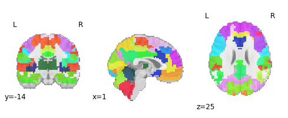

```python
#visualize atlas
from nilearn import plotting
plotting.plot_roi(atlasFile, draw_cross = False)
```

Now I will generate correlation matrices for each subject and then add them to the phenotypic data.

```python
from nilearn.input_data import NiftiLabelsMasker
from nilearn.connectome import ConnectivityMeasure

#create mask
myMask = NiftiLabelsMasker(labels_img=atlasFile, standardize=True, memory='nilearn_cache',verbose=1)

#initializing correlation measure
correlationMeasure = ConnectivityMeasure(kind='correlation', vectorize=True, discard_diagonal=True)
```

```python
import pandas as pd

#initializing empty dataframe
allFeatures = pd.DataFrame(columns=['features', 'file'])

for num,subject in enumerate(data.func):
    timeSeries = myMask.fit_transform(subject, confounds=data.confounds[num])

    #creating a region x region correlation matrix
    correlationMatrix = correlationMeasure.fit_transform([timeSeries])[0]

    #adding features and filename to dataframe
    allFeatures = allFeatures.append({'features': correlationMatrix, 'file': data.func[num]},ignore_index=True)

    #keeping track of status
    print('finished %s of %s' %(num+1,len(data.func)))
```

[output not shown]

[output cut: 51 more lines]

[output not shown]

```python
#create pandas dataframe of features and phenotypic data
complete = pandas.merge(myPheno, allFeatures, left_on = 'path', right_on='file')
```

Here is the pandas dataframe with complete demographic information and a column that has the correlation matrix for each subject as an array

```python
complete
```

|  | Unnamed: 0 | Subject | Rest.Scan | MeanFD | NumFD_greater_than_0.20 | rootMeanSquareFD | FDquartile.top1.4thFD. | PercentFD_greater_than_0.20 | MeanDVARS | MeanFD_Jenkinson | ... | sess_2_rest_1 | sess_2_rest_1_eyes | sess_2_rest_2 | sess_2_rest_2_eyes | sess_2_anat_1 | defacing_ok | defacing_notes | path | features | file |
| --- | --- | --- | --- | --- | --- | --- | --- | --- | --- | --- | --- | --- | --- | --- | --- | --- | --- | --- | --- | --- | --- |
| 0 | 1 | 2014113 | rest_1 | 0.0576 | 2 | 0.2400 | 0.0944 | 1.6000 | 16.1677 | 1.3868 | ... | NaN | NaN | NaN | NaN | NaN | yes | NaN | /Users/shubhaviarya/nilearn_data/adhd/data/201... | [0.099702746, -0.18896824, 0.04915938, 0.25369... | /Users/shubhaviarya/nilearn_data/adhd/data/201... |
| 1 | 2 | 3902469 | rest_1 | 0.0580 | 0 | 0.2409 | 0.0931 | 0.0000 | 17.4188 | 1.2040 | ... | NaN | NaN | NaN | NaN | NaN | NaN | NaN | /Users/shubhaviarya/nilearn_data/adhd/data/390... | [0.089416295, -0.0077906298, 0.15645671, 0.289... | /Users/shubhaviarya/nilearn_data/adhd/data/390... |
| 2 | 3 | 4275075 | rest_1 | 0.0789 | 0 | 0.2808 | 0.1520 | 0.0000 | 17.7796 | 1.8105 | ... | NaN | NaN | NaN | NaN | NaN | NaN | NaN | /Users/shubhaviarya/nilearn_data/adhd/data/427... | [0.06138464, -0.038983215, 0.04661025, 0.08573... | /Users/shubhaviarya/nilearn_data/adhd/data/427... |
| 3 | 4 | 7774305 | rest_1 | 0.0679 | 0 | 0.2606 | 0.1054 | 0.0000 | 16.7169 | 1.5137 | ... | NaN | NaN | NaN | NaN | NaN | yes | defaced part of front skull/brain | /Users/shubhaviarya/nilearn_data/adhd/data/777... | [-0.05577563, -0.22510526, 0.31184578, 0.33335... | /Users/shubhaviarya/nilearn_data/adhd/data/777... |
| 4 | 5 | 1019436 | rest_1 | 0.0904 | 0 | 0.3006 | 0.1927 | 0.0000 | 19.6124 | 1.6769 | ... | NaN | NaN | NaN | NaN | NaN | yes | NaN | /Users/shubhaviarya/nilearn_data/adhd/data/101... | [0.24521679, -0.13658871, -0.05749052, 0.24750... | /Users/shubhaviarya/nilearn_data/adhd/data/101... |
| 5 | 6 | 3699991 | rest_1 | 0.1113 | 15 | 0.3337 | 0.2524 | 9.8039 | 19.8704 | 2.6121 | ... | NaN | NaN | NaN | NaN | NaN | NaN | NaN | /Users/shubhaviarya/nilearn_data/adhd/data/369... | [0.0646003, -0.029432628, 0.16057898, 0.293279... | /Users/shubhaviarya/nilearn_data/adhd/data/369... |
| 6 | 7 | 3154996 | rest_1 | 0.0881 | 0 | 0.2968 | 0.1619 | 0.0000 | 18.6120 | 1.8118 | ... | NaN | NaN | NaN | NaN | NaN | NaN | NaN | /Users/shubhaviarya/nilearn_data/adhd/data/315... | [0.2347607, -0.31418574, 0.090578176, 0.027886... | /Users/shubhaviarya/nilearn_data/adhd/data/315... |
| 7 | 8 | 3884955 | rest_1 | 0.0988 | 8 | 0.3144 | 0.1881 | 6.4000 | 17.3609 | 1.9543 | ... | NaN | NaN | NaN | NaN | NaN | NaN | NaN | /Users/shubhaviarya/nilearn_data/adhd/data/388... | [-0.19471535, -0.19354574, 0.055207245, 0.1772... | /Users/shubhaviarya/nilearn_data/adhd/data/388... |
| 8 | 9 | 27034 | rest_1 | 0.0484 | 1 | 0.2201 | 0.0860 | 0.3831 | 21.5895 | 0.9262 | ... | NaN | NaN | NaN | NaN | NaN | NaN | NaN | /Users/shubhaviarya/nilearn_data/adhd/data/002... | [0.27563015, 0.10243464, 0.22862752, 0.1330881... | /Users/shubhaviarya/nilearn_data/adhd/data/002... |
| 9 | 10 | 4134561 | rest_1 | 0.0439 | 4 | 0.2095 | 0.0849 | 1.5267 | 25.0028 | 0.9207 | ... | NaN | NaN | NaN | NaN | NaN | yes | NaN | /Users/shubhaviarya/nilearn_data/adhd/data/413... | [0.056150664, 0.16192757, 0.20446236, 0.245703... | /Users/shubhaviarya/nilearn_data/adhd/data/413... |
| 10 | 11 | 27018 | rest_1 | 0.0622 | 5 | 0.2494 | 0.1221 | 1.9157 | 19.7246 | 1.0707 | ... | NaN | NaN | NaN | NaN | NaN | NaN | NaN | /Users/shubhaviarya/nilearn_data/adhd/data/002... | [-0.017702665, -0.0321446, -0.2318833, -0.0850... | /Users/shubhaviarya/nilearn_data/adhd/data/002... |
| 11 | 12 | 6115230 | rest_1 | 0.0539 | 2 | 0.2322 | 0.1040 | 0.7634 | 23.1873 | 1.1637 | ... | NaN | NaN | NaN | NaN | NaN | yes | deface front part of skull/brain | /Users/shubhaviarya/nilearn_data/adhd/data/611... | [0.048174337, -0.038958076, 0.34462577, 0.0785... | /Users/shubhaviarya/nilearn_data/adhd/data/611... |
| 12 | 13 | 27037 | rest_1 | 0.0686 | 0 | 0.2619 | 0.1121 | 0.0000 | 21.8621 | 1.5228 | ... | NaN | NaN | NaN | NaN | NaN | NaN | NaN | /Users/shubhaviarya/nilearn_data/adhd/data/002... | [0.036746763, 0.12673074, -0.14303601, 0.02012... | /Users/shubhaviarya/nilearn_data/adhd/data/002... |
| 13 | 14 | 8409791 | rest_1 | 0.0567 | 4 | 0.2380 | 0.1068 | 1.5267 | 22.7119 | 1.0041 | ... | NaN | NaN | NaN | NaN | NaN | yes | NaN | /Users/shubhaviarya/nilearn_data/adhd/data/840... | [0.3284404, 0.14619106, 0.18256181, 0.24275021... | /Users/shubhaviarya/nilearn_data/adhd/data/840... |
| 14 | 15 | 27011 | rest_1 | 0.1212 | 1 | 0.3482 | 0.2302 | 0.3817 | 21.6233 | 2.4654 | ... | NaN | NaN | NaN | NaN | NaN | NaN | NaN | /Users/shubhaviarya/nilearn_data/adhd/data/002... | [0.2435922, 0.036132835, 0.088765755, -0.05950... | /Users/shubhaviarya/nilearn_data/adhd/data/002... |
| 15 | 16 | 3007585 | rest_1 | 0.0528 | 0 | 0.2298 | 0.1094 | 0.0000 | 25.1240 | 0.9446 | ... | NaN | NaN | NaN | NaN | NaN | NaN | NaN | /Users/shubhaviarya/nilearn_data/adhd/data/300... | [0.17836411, -0.057775058, -0.09736896, 0.0838... | /Users/shubhaviarya/nilearn_data/adhd/data/300... |
| 16 | 17 | 8697774 | rest_1 | 0.0527 | 0 | 0.2296 | 0.0800 | 0.0000 | 2.0728 | 1.1396 | ... | NaN | NaN | NaN | NaN | NaN | NaN | NaN | /Users/shubhaviarya/nilearn_data/adhd/data/869... | [0.26257858, -0.01471501, 0.3056692, 0.4140661... | /Users/shubhaviarya/nilearn_data/adhd/data/869... |
| 17 | 18 | 9750701 | rest_1 | 0.0654 | 0 | 0.2557 | 0.1026 | 0.0000 | 2.1544 | 1.3514 | ... | NaN | NaN | NaN | NaN | NaN | yes | NaN | /Users/shubhaviarya/nilearn_data/adhd/data/975... | [0.34606516, -0.11297555, 0.12377982, 0.393092... | /Users/shubhaviarya/nilearn_data/adhd/data/975... |
| 18 | 19 | 10064 | rest_1 | 0.0623 | 0 | 0.2496 | 0.0926 | 0.0000 | 2.0866 | 0.9943 | ... | NaN | NaN | NaN | NaN | NaN | NaN | NaN | /Users/shubhaviarya/nilearn_data/adhd/data/001... | [0.05906585, 0.023257246, 0.2309234, 0.2589358... | /Users/shubhaviarya/nilearn_data/adhd/data/001... |
| 19 | 20 | 21019 | rest_1 | 0.0575 | 0 | 0.2398 | 0.0955 | 0.0000 | 2.0339 | 1.1973 | ... | NaN | NaN | NaN | NaN | NaN | yes | NaN | /Users/shubhaviarya/nilearn_data/adhd/data/002... | [0.29425192, 0.034056704, 0.10205513, 0.091403... | /Users/shubhaviarya/nilearn_data/adhd/data/002... |
| 20 | 21 | 10042 | rest_1 | 0.0559 | 0 | 0.2365 | 0.0922 | 0.0000 | 2.2915 | 1.0089 | ... | NaN | NaN | NaN | NaN | NaN | NaN | NaN | /Users/shubhaviarya/nilearn_data/adhd/data/001... | [0.38576013, 0.19752927, -0.034569763, 0.26150... | /Users/shubhaviarya/nilearn_data/adhd/data/001... |
| 21 | 22 | 10128 | rest_1 | 0.0689 | 0 | 0.2624 | 0.1132 | 0.0000 | 2.1422 | 1.2641 | ... | NaN | NaN | NaN | NaN | NaN | NaN | NaN | /Users/shubhaviarya/nilearn_data/adhd/data/001... | [0.46423686, -0.05559261, -0.18878943, 0.42604... | /Users/shubhaviarya/nilearn_data/adhd/data/001... |
| 22 | 23 | 2497695 | rest_1 | 0.0482 | 0 | 0.2195 | 0.0739 | 0.0000 | 2.1269 | 1.0257 | ... | NaN | NaN | NaN | NaN | NaN | yes | NaN | /Users/shubhaviarya/nilearn_data/adhd/data/249... | [0.3090028, -0.20101869, 0.15623687, 0.123762,... | /Users/shubhaviarya/nilearn_data/adhd/data/249... |
| 23 | 24 | 4164316 | rest_1 | 0.0774 | 11 | 0.2782 | 0.1786 | 6.2147 | 2.2470 | 1.4483 | ... | NaN | NaN | NaN | NaN | NaN | yes | NaN | /Users/shubhaviarya/nilearn_data/adhd/data/416... | [0.18266006, 0.053213164, 0.13737457, 0.301389... | /Users/shubhaviarya/nilearn_data/adhd/data/416... |
| 24 | 25 | 1552181 | rest_1 | 0.0408 | 0 | 0.2021 | 0.0665 | 0.0000 | 12.8089 | 0.8528 | ... | NaN | NaN | NaN | NaN | NaN | NaN | NaN | /Users/shubhaviarya/nilearn_data/adhd/data/155... | [0.24331683, 0.11997671, 0.15477629, 0.365618,... | /Users/shubhaviarya/nilearn_data/adhd/data/155... |
| 25 | 26 | 4046678 | rest_1 | 0.1139 | 9 | 0.3375 | 0.2162 | 11.3924 | 16.4176 | 2.7597 | ... | NaN | NaN | NaN | NaN | NaN | NaN | NaN | /Users/shubhaviarya/nilearn_data/adhd/data/404... | [0.26400584, 0.09710038, 0.16714007, 0.4725717... | /Users/shubhaviarya/nilearn_data/adhd/data/404... |
| 26 | 27 | 23012 | rest_1 | 0.0569 | 0 | 0.2386 | 0.1044 | 0.0000 | 16.8908 | 1.3229 | ... | NaN | NaN | NaN | NaN | NaN | NaN | NaN | /Users/shubhaviarya/nilearn_data/adhd/data/002... | [0.29637876, -0.3057408, -0.2015853, 0.0247812... | /Users/shubhaviarya/nilearn_data/adhd/data/002... |
| 27 | 28 | 1679142 | rest_1 | 0.1482 | 0 | 0.3849 | 0.2947 | 0.0000 | 18.4691 | 2.2433 | ... | NaN | NaN | NaN | NaN | NaN | yes | NaN | /Users/shubhaviarya/nilearn_data/adhd/data/167... | [0.2544344, 0.14044009, -0.04573749, 0.4189829... | /Users/shubhaviarya/nilearn_data/adhd/data/167... |
| 28 | 29 | 1206380 | rest_1 | 0.0719 | 1 | 0.2681 | 0.1294 | 1.2658 | 16.9621 | 2.1269 | ... | NaN | NaN | NaN | NaN | NaN | yes | NaN | /Users/shubhaviarya/nilearn_data/adhd/data/120... | [0.20193276, 0.08832485, 0.20624438, 0.2480782... | /Users/shubhaviarya/nilearn_data/adhd/data/120... |
| 29 | 30 | 23008 | rest_1 | 0.0801 | 7 | 0.2831 | 0.1710 | 8.9744 | 13.4263 | 1.7741 | ... | NaN | NaN | NaN | NaN | NaN | yes | NaN | /Users/shubhaviarya/nilearn_data/adhd/data/002... | [-0.031444725, 0.14899744, 0.22901624, 0.28501... | /Users/shubhaviarya/nilearn_data/adhd/data/002... |
| 30 | 31 | 4016887 | rest_1 | 0.0879 | 3 | 0.2965 | 0.1516 | 3.7975 | 17.4466 | 2.5734 | ... | NaN | NaN | NaN | NaN | NaN | NaN | NaN | /Users/shubhaviarya/nilearn_data/adhd/data/401... | [0.26914153, 0.21769321, 0.02183819, 0.5068154... | /Users/shubhaviarya/nilearn_data/adhd/data/401... |
| 31 | 32 | 1418396 | rest_1 | 0.0713 | 2 | 0.2670 | 0.1471 | 2.5316 | 17.4328 | 1.8083 | ... | NaN | NaN | NaN | NaN | NaN | NaN | NaN | /Users/shubhaviarya/nilearn_data/adhd/data/141... | [0.13874619, 0.22254132, 0.3190973, 0.3857753,... | /Users/shubhaviarya/nilearn_data/adhd/data/141... |
| 32 | 33 | 2950754 | rest_1 | 0.0523 | 2 | 0.2287 | 0.0864 | 0.8439 | 20.3974 | 1.1459 | ... | NaN | NaN | NaN | NaN | NaN | yes | NaN | /Users/shubhaviarya/nilearn_data/adhd/data/295... | [0.34258807, 0.039793734, 0.34796214, 0.254069... | /Users/shubhaviarya/nilearn_data/adhd/data/295... |
| 33 | 34 | 3994098 | rest_1 | 0.0547 | 0 | 0.2340 | 0.0993 | 0.0000 | 21.5907 | 1.3200 | ... | NaN | NaN | NaN | NaN | NaN | yes | NaN | /Users/shubhaviarya/nilearn_data/adhd/data/399... | [0.17507254, -0.058690447, 0.28509158, 0.48999... | /Users/shubhaviarya/nilearn_data/adhd/data/399... |
| 34 | 35 | 3520880 | rest_1 | 0.0509 | 0 | 0.2255 | 0.0743 | 0.0000 | 17.8432 | 1.3762 | ... | NaN | NaN | NaN | NaN | NaN | NaN | NaN | /Users/shubhaviarya/nilearn_data/adhd/data/352... | [0.30443344, 0.21947744, 0.14888616, 0.4287756... | /Users/shubhaviarya/nilearn_data/adhd/data/352... |
| 35 | 36 | 1517058 | rest_1 | 0.0733 | 0 | 0.2708 | 0.1450 | 0.0000 | 18.3401 | 1.4190 | ... | NaN | NaN | NaN | NaN | NaN | NaN | NaN | /Users/shubhaviarya/nilearn_data/adhd/data/151... | [0.25477687, 0.19738586, 0.22110052, 0.3100055... | /Users/shubhaviarya/nilearn_data/adhd/data/151... |
| 36 | 37 | 9744150 | rest_1 | 0.0547 | 0 | 0.2338 | 0.0966 | 0.0000 | 19.1607 | 1.4302 | ... | NaN | NaN | NaN | NaN | NaN | NaN | NaN | /Users/shubhaviarya/nilearn_data/adhd/data/974... | [0.14122805, 0.039847065, 0.13463525, 0.395856... | /Users/shubhaviarya/nilearn_data/adhd/data/974... |
| 37 | 38 | 1562298 | rest_1 | 0.0722 | 2 | 0.2686 | 0.1246 | 0.8439 | 25.0944 | 1.8281 | ... | NaN | NaN | NaN | NaN | NaN | NaN | NaN | /Users/shubhaviarya/nilearn_data/adhd/data/156... | [0.18526037, 0.17634061, 0.4151504, 0.49105507... | /Users/shubhaviarya/nilearn_data/adhd/data/156... |
| 38 | 39 | 3205761 | rest_1 | 0.0679 | 8 | 0.2605 | 0.1572 | 3.3755 | 23.8591 | 1.3947 | ... | NaN | NaN | NaN | NaN | NaN | NaN | NaN | /Users/shubhaviarya/nilearn_data/adhd/data/320... | [0.063356735, 0.0003985194, 0.0142550655, 0.29... | /Users/shubhaviarya/nilearn_data/adhd/data/320... |
| 39 | 40 | 3624598 | rest_1 | 0.0653 | 14 | 0.2556 | 0.1404 | 5.9072 | 8.2800 | 1.6411 | ... | NaN | NaN | NaN | NaN | NaN | NaN | NaN | /Users/shubhaviarya/nilearn_data/adhd/data/362... | [0.3069562, -0.089238256, 0.09645871, 0.333239... | /Users/shubhaviarya/nilearn_data/adhd/data/362... |

40 rows × 69 columns

## Visualizing Connectivity

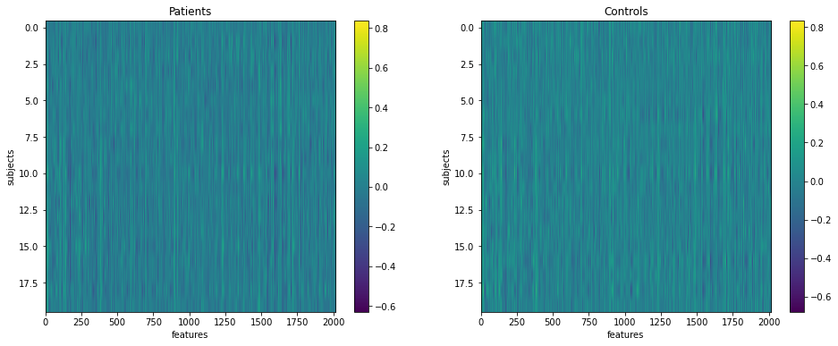

```python
import matplotlib.pyplot as plt
from matplotlib.pyplot import figure, savefig

patientFeatures = list(complete.loc[complete['subject_type']=='Patient']['features'])
controlFeatures = list(complete.loc[complete['subject_type']=='Control']['features'])

figure(figsize=(16,6))

plt.subplot(1,2,1)
plt.imshow(patientFeatures, aspect='auto')
plt.colorbar()
plt.title('Patients')
plt.xlabel('features')
plt.ylabel('subjects')

plt.subplot(1,2,2)
plt.imshow(controlFeatures, aspect='auto')
plt.colorbar()
plt.title('Controls')
plt.xlabel('features')
plt.ylabel('subjects')

savefig('myFeatures.png', transparent=True)
```

## Classification

I will first split the data into training and testing sets, with a ratio of 80/20.

```python
from sklearn.model_selection import train_test_split

#Split the sample to training/testing sets with a 80/20 ratio

x_Train, xVal, y_Train, yVal = train_test_split(list(complete['features']),#x \
                                                complete['subject_type'], #y \
                                                 test_size = 0.2, #80/20 ratio \
                                                 shuffle = True, #shuffle dataset
                                                 stratify = complete['subject_type'], \
                                                 random_state = 242)
```

I will be using 10-fold crosss validation to get a rough benchmark of performance for each classifier. I will use F1 as my performance metric. After each run I will look at the performance of the classifier across the folds as well as the average performance.

```python
#building SVC classifier
from sklearn.svm import SVC
my_svc = SVC(kernel='linear')
```

```python
#F1 score by averaging each fold
from sklearn.model_selection import cross_val_score
import numpy as np
svcScore = cross_val_score(my_svc, x_Train, y_Train, cv=10, scoring='f1_macro')
print(np.mean(svcScore))
print(svcScore)
```

```
0.7233333333333334
[1.         1.         0.25       0.66666667 0.25       1.
 0.4        1.         1.         0.66666667]
```

Based on above results, Linear SVC has a good performance as seen above with an average F1 score of ~0.72.

I will now try gradient boosting as my classifier. The gradient boost model will use a greater number of estimators and a larger max depth than the defaults in order to try and improve performance.

```python
#building gradient boost classifier
from sklearn.ensemble import GradientBoostingClassifier
myBoost = GradientBoostingClassifier(n_estimators=500, \
                                    max_depth=4, \
                                    random_state=242)
```

```python
#train model
myBoost.fit(x_Train, y_Train)

#F1 score by averaging each fold
from sklearn.model_selection import cross_val_score
import numpy as np
myBoostScore = cross_val_score(myBoost, x_Train, y_Train, cv=10, scoring='f1_macro')
print(np.mean(myBoostScore))
print(myBoostScore)
```

```
0.38499999999999995
[0.73333333 0.5        0.         0.4        0.25       0.25
 0.4        0.25       0.66666667 0.4       ]
```

Based on above results, the gradient boost model seems to be highly variable and isn't comparable to the performance of the SVC. Next, I will try K nearest neighbors as my classifier.

```python
#KNN
from sklearn.neighbors import KNeighborsClassifier

knn = KNeighborsClassifier()

knnScore = cross_val_score(knn, x_Train, y_Train, cv=10, scoring='f1_macro')
print(np.mean(knnScore))
print(knnScore)
```

```
0.4716666666666667
[1.         0.73333333 0.25       0.25       0.25       0.4
 0.66666667 0.25       0.25       0.66666667]
```

Now I will try a Random Forest classifier. I will increase the number of estimators like I did with the gradient boost model.

```python
#Random Forest
from sklearn.ensemble import RandomForestClassifier

myRfc = RandomForestClassifier(n_estimators = 500, random_state = 242)

rfcScore = cross_val_score(myRfc, x_Train, y_Train, cv=10, scoring='f1_macro')
print(np.mean(rfcScore))
print(rfcScore)
```

```
0.5233333333333332
[0.73333333 0.5        0.25       0.66666667 0.25       1.
 0.66666667 0.66666667 0.25       0.25      ]
```

Based on above results, the Random Forest model performed alright but not as much as the linear SVC. With some parameter adjustment and modifications, the same performance might be achieveable but since the random forest classifier is more complex, and takes longer to train, I will use SVC as the final model.

### Parameter Tweaking

I will now see if I can improve the performance of my SVC model by tweaking the hyperparameters. But with linear SVC, the only option I have to tweak is the `C` parameter.

I will create a range of values for `C` and then compare each using cross validation.

```python
from sklearn.model_selection import validation_curve

cRange = 10. ** np.arange(-3,8) # a range of values for C

trainScores, validScores = validation_curve(my_svc, x_Train, y_Train,\
                                           param_name = "C", param_range=cRange, \
                                           cv=10,\
                                           scoring='f1_macro')
```

```python
#Creating a Pandas dataframe of the results
t_scores = pandas.DataFrame(trainScores).stack().reset_index()
t_scores.columns = ['C', 'Fold', 'Score']
t_scores.loc[:,'Type'] = ['Train' for x in range(len(t_scores))]

v_scores = pandas.DataFrame(validScores).stack().reset_index()
v_scores.columns = ['C', 'Fold', 'Score']
v_scores.loc[:, 'Type'] = ['Validate' for x in range(len(v_scores))]

val_curves = pandas.concat([t_scores, v_scores]).reset_index(drop=True)
```

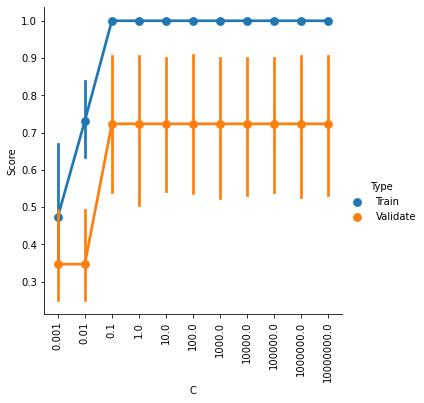

```python
#Plotting the performance of different values of C
import seaborn as sns
myPlot = sns.catplot(x='C', y='Score', hue='Type', data=val_curves, kind='point')

myPlot.set_xticklabels(cRange, rotation=90)
```

Based on the above plot, the model seems to perform best at C value of 0.1 but it's a minor difference. I will try one more thing now.

I will try to change the SVC kernel to the default 'rbf' which would let me adjust C and gamma. I will use a grid search to see if optimizing the rbf kernel would give a better result than a linear kernel.

```python
#RBF SVC classifier
from sklearn.model_selection import GridSearchCV

rbf_svc = SVC(kernel='rbf')

cRange = 10. ** np.arange(-3,8)
gammaRange = 10. ** np.arange(-8,3)

param_grid = dict(gamma=gammaRange, C=cRange)

myGrid = GridSearchCV(rbf_svc, param_grid=param_grid, cv=10)

myGrid.fit(x_Train, y_Train)
```

```
GridSearchCV(cv=10, estimator=SVC(),
             param_grid={'C': array([1.e-03, 1.e-02, 1.e-01, 1.e+00, 1.e+01, 1.e+02, 1.e+03, 1.e+04,
       1.e+05, 1.e+06, 1.e+07]),
                         'gamma': array([1.e-08, 1.e-07, 1.e-06, 1.e-05, 1.e-04, 1.e-03, 1.e-02, 1.e-01,
       1.e+00, 1.e+01, 1.e+02])})
```

```python
print(myGrid.best_params_)
```

```
{'C': 10000000.0, 'gamma': 1e-08}
```

```python
rbf_svc = SVC(kernel='rbf', C=100.0, gamma=0.001)

rbf_svcScore = cross_val_score(rbf_svc, x_Train, y_Train, cv=10, scoring='f1_macro')
print(np.mean(rbf_svcScore))
print(rbf_svcScore)
```

```
0.7233333333333334
[1.         1.         0.25       0.66666667 0.25       1.
 0.4        1.         1.         0.66666667]
```

## Testing the model

I will now run the model on the remaining data (testing data) and check how accurately it performs.

```python
#Testing
from sklearn.metrics import f1_score, accuracy_score
rbf_svc.fit(x_Train, y_Train)
predictedResult = rbf_svc.predict(xVal)
print('F1:', f1_score(yVal, predictedResult, pos_label='Patient'))
print('Accuracy:', accuracy_score(yVal, predictedResult))
```

```
F1: 0.5454545454545454
Accuracy: 0.375
```

```
[[0 4]
 [1 3]]
```

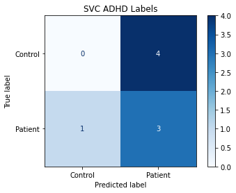

```python
import matplotlib.pyplot as plt
from sklearn.metrics import plot_confusion_matrix

myDisplay = plot_confusion_matrix(rbf_svc, xVal, yVal, cmap=plt.cm.Blues, normalize=None)

myDisplay.ax_.set_title('SVC ADHD Labels')
print(myDisplay.confusion_matrix)
```

## SUMMARY

### Data Cleaning

Data was prepared in this study by extracting subject-IDs from the nifti file paths and then were merged with the phenotypic data to create the final names. This was done to easily subset attributes for creating data visualizations. The last step was to generate time series and correlation matrix for each subject and the correlation matrices were added to the phenotypic data for each subject.

### Classification

My primary goal with this project was to predict an ADHD diagnosis from fMRI data. I tried and assesed various machine learning techniques on the dataset. I split the dataset into 80/20 for training and testing. Each classifier model was used on the training data using a 10-fold cross validation. I used the F1 score as a measure to assess performance. I also used a grid search to fine tune the hyperparameters.

## RESULTS

Classifier models:

1. Linear Support Vector Machine (average CV = 0.72 , min F1 score = 0.25, max F1 score = 1.0)
2. Gradient Boost (average CV = 0.38 , min F1 score = 0., max F1 score = 0.73)
3. K Nearest Neighbors(average CV = 0.47, min F1 score = 0.25, max F1 score = 1.0)
4. Random Forest (average CV = 0.52, min F1 score = 0.25, max F1 score = 1.0)
5. RBF Support Vector Machine (average CV = 0.72 , min F1 score = 0.25, max F1 score = 1.0)

### Conclusion and Limitations

I gained a lot of experience working with fMRI data and applying machine learning techniques to neuroimaging data analysis. The available documentation, readings and textbook made it easier for me to learn and apply the various tools and techniques I implemented in this project. I was also able to further improve my programming skills specifically in relation to its applications to fMRI data. In the future, I would like to further improve upon my fMRI analysis skills and experiment with more advanced machine learning algorithms.